#### **General Health**

One of the variables within the dataset contains self-reported general health status from the survey respondents. The participants were asked to rate their general health as “Excellent,” “Very good,” “Good,” “Fair,” or “Poor.” Some participants did refuse to answer and others responded “Don’t know.”

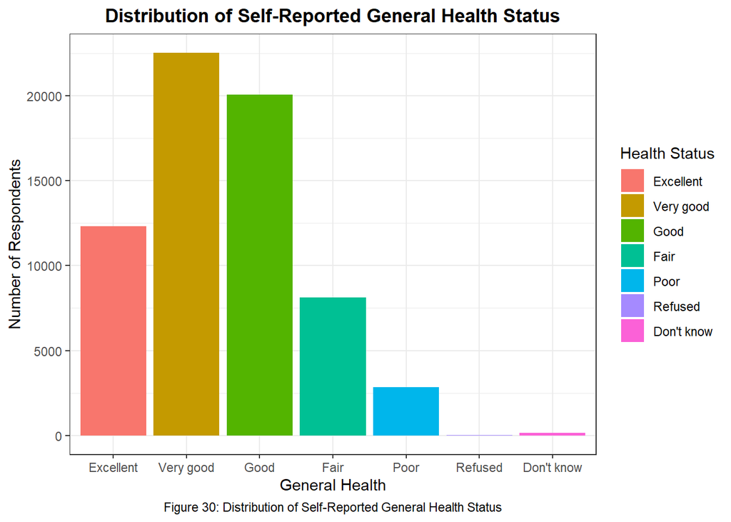

The general distribution is as shown above in Figure 30: A majority of respondents consider themselves in ‘very good’ or ‘good’ health. Interestingly, this slightly contradicts the BMI, objective measurement of health, where a larger majority of individuals are categorized as ‘overweight.’

**- How does an individual’s health (BMI and general health) relate to the amount of time they spend being physically active?**

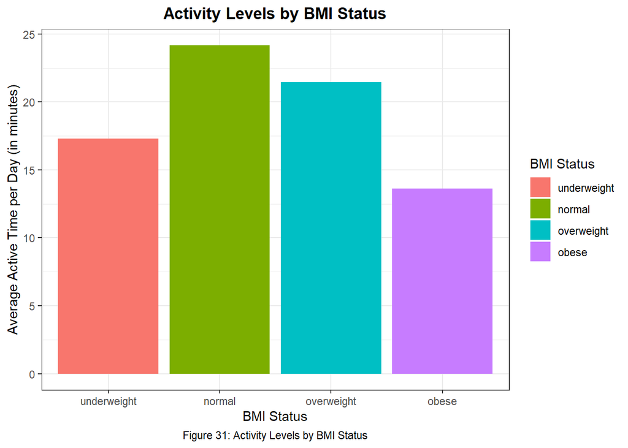

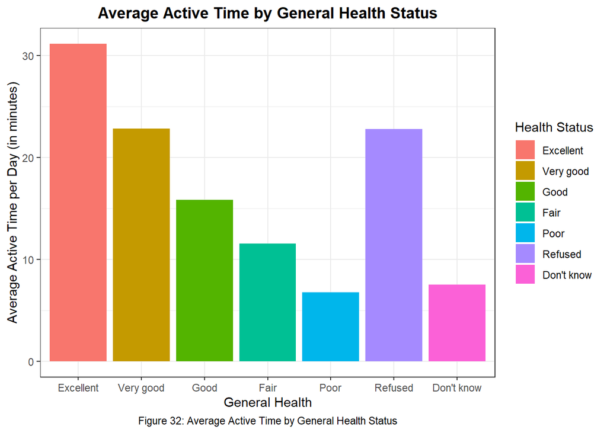

Figure 31 and Figure 32 show the average active time per day by BMI status and by General health status, respectively. Here, there is a general positive correlation between an individual’s amount of activity time and their perceived health level. That is, those who consider themselves in good health tend to be more active.

## **Work-Life Balance**

The last section of this report provides insight about how Americans balance their work and other activities in relation to the presence of children. We specifically focused on finding the relationship between work and travel, religious activities, and social activities.

**- How does the presence or lack of children affect time-use?**

In order to better visualize how the data is shaped between respondents with children and those without, we created discrete bins of the time data for several categories: Time spent working, time spent traveling, time spent in religious activities, and time spent in social activities. We tried to break the discrete time values up into units which we felt reasonable, based on some quick data explorations when we first received the data set. We also changed the 1 or 0 values under the “Children in the household” variable, HH_CHILD, to “children” and “no children.”

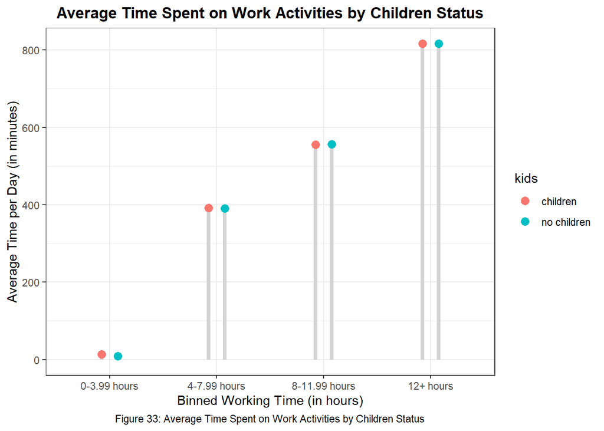

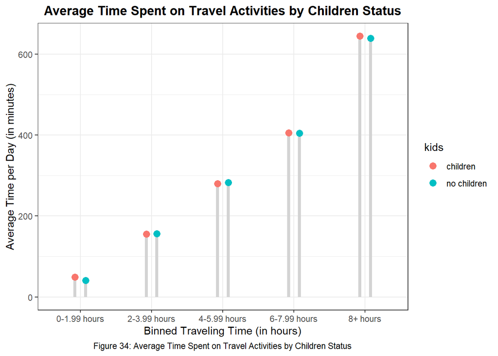

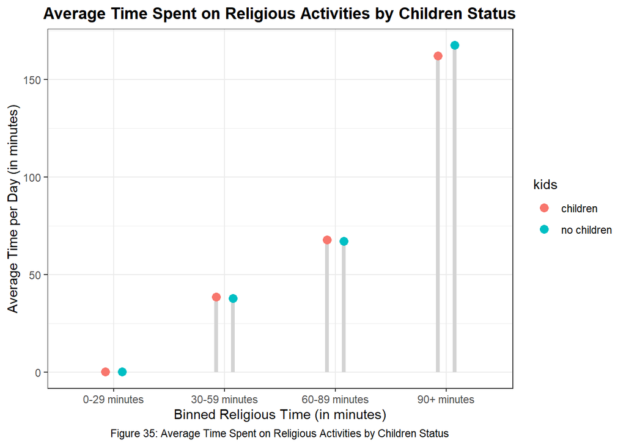

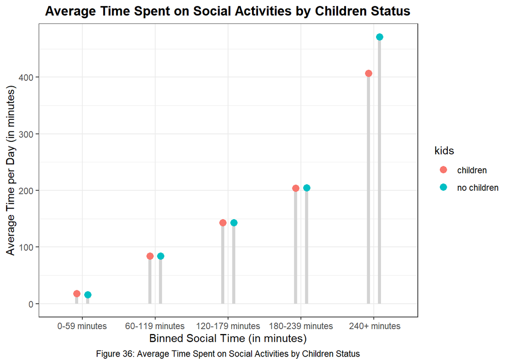

**- How does an individual’s work time correlate to their other activities?**

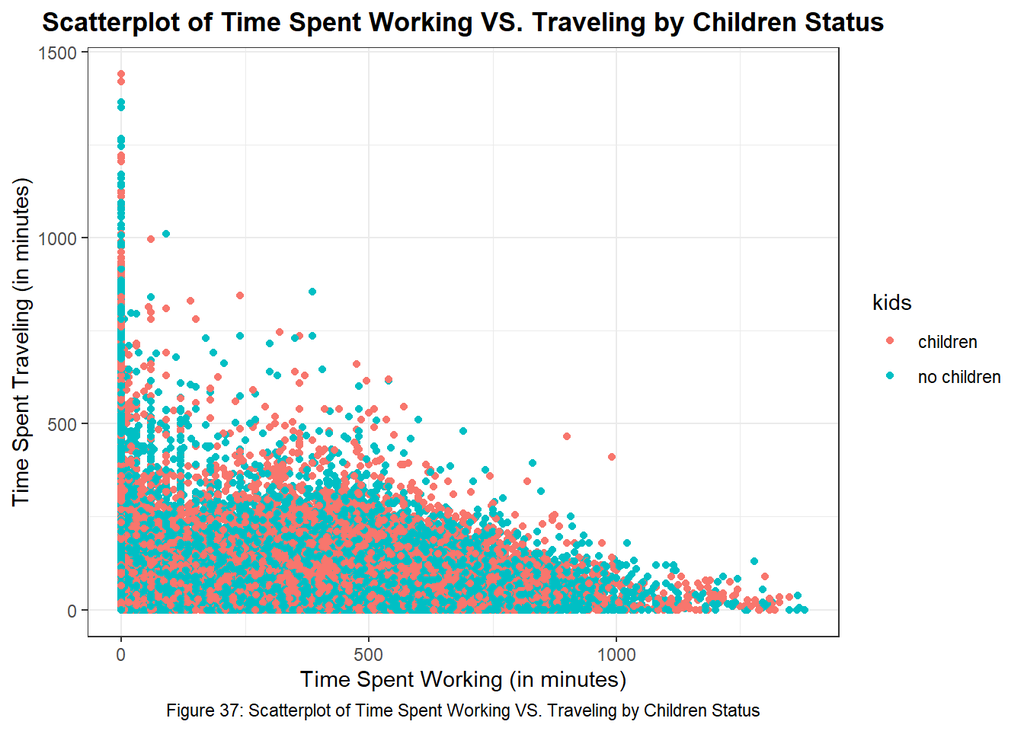

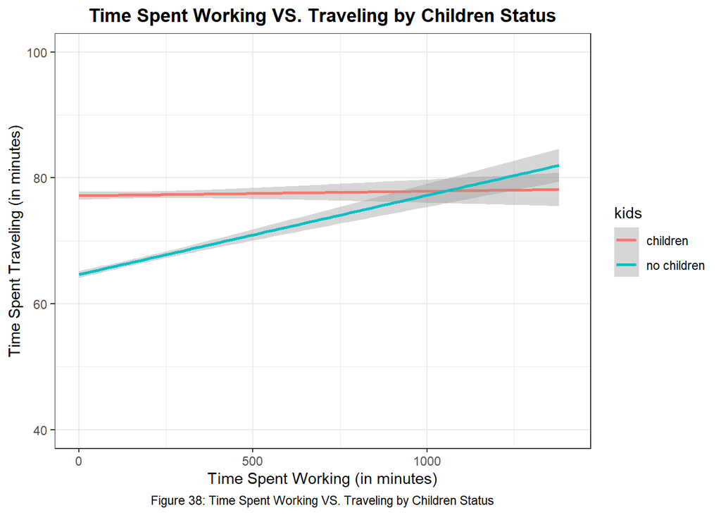

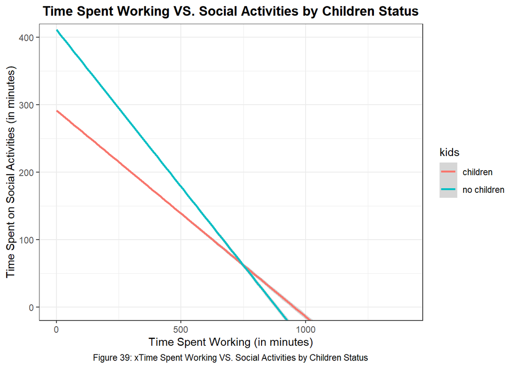

To better estimate how respondents use their time, and to look for signs of interaction or correlation between different activities, we used a regression line on our data. In detail, the plots have the work time on x-axis and other activity time on y-axis. And the lines are divided into 2 lines, one corresponding to children, and the other one corresponding to no children. Based on Figure 38, where it shows the relationship between travel time and work time, we see that respondents with children report about the same amount of travel time as time spent working increases. However, for the respondents with no children, there is a steeper slope indicating that more time working might correlate to more time spent traveling. Looking at Figure 39, we observe among both respondents with children and those without, as minutes work increases, the amount of social time decreases.

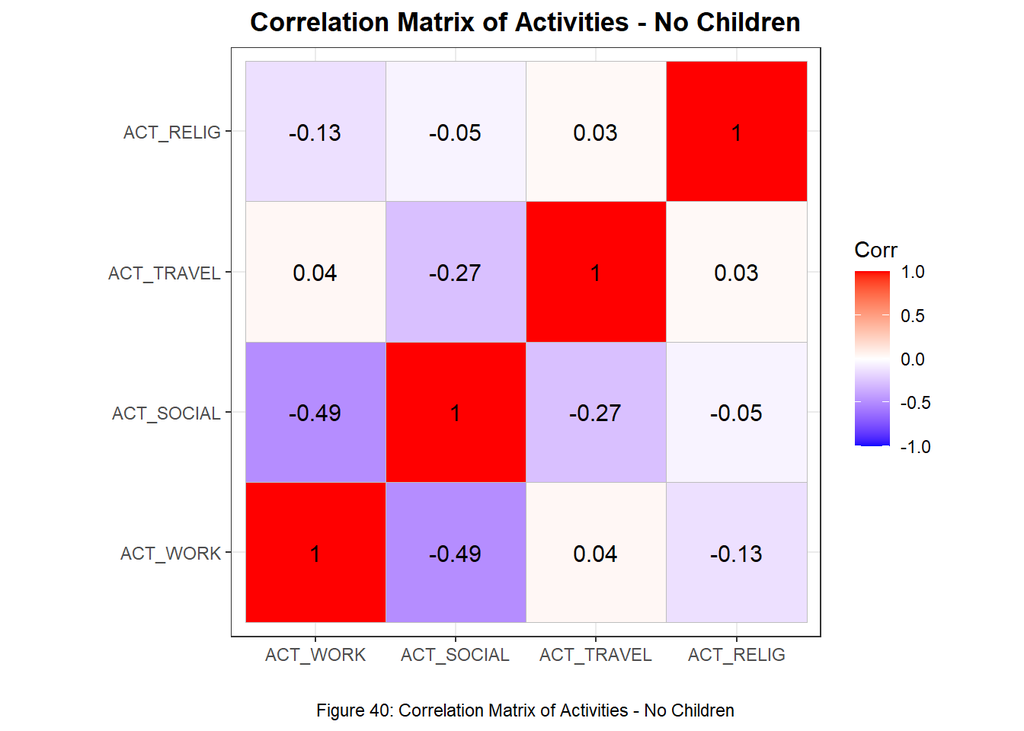

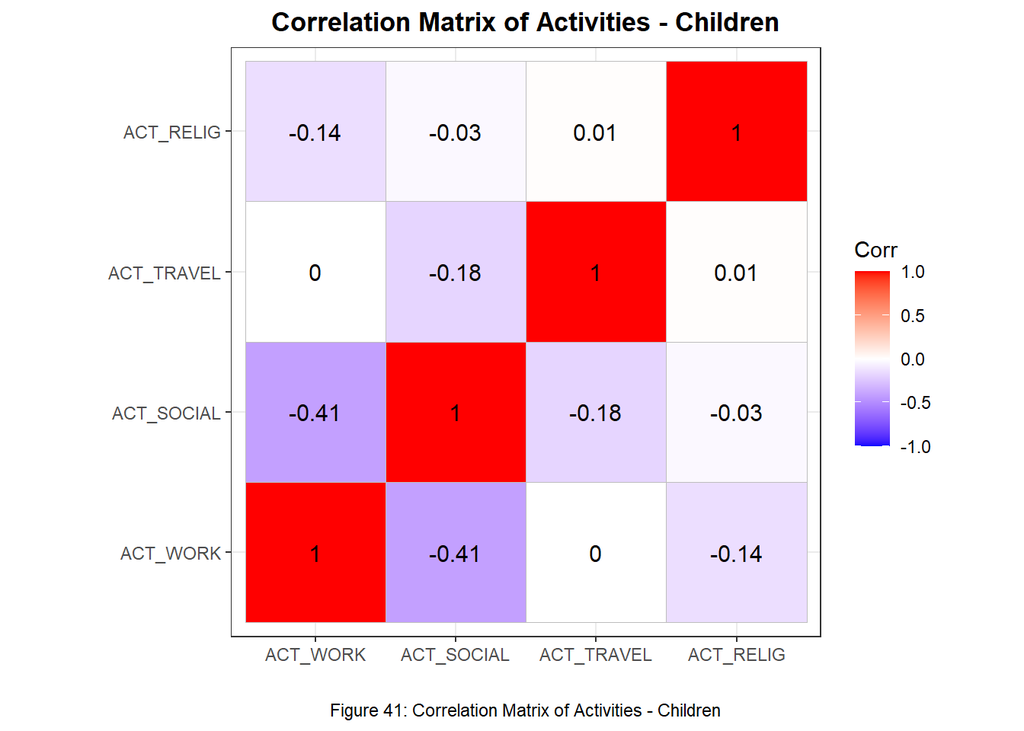

We also used a correlation matrix of our time-based variables to understand the numerical association between them. According to Figure 40, among the no children group, there appears a moderate negative relation between work and social minutes, indicating that as minutes in work increase, minutes engaged in social time decrease. We should not be surprised at this based on the example charts from above. Figure 41 illustrates the correlations for the households with children. This group has a slightly lower strength of the possible correlations between our categories.

## **Personal Contributions**

Our Github repository address is https://github.com/tessamendoza/ds202_project.git.

#### **Jaeyeon Won**

As a project coordinator, not only did I contribute to the Exploratoy analysis, introduction, and conclusion sections of this paper, but I also supervised the overall project. I joined all team members’ individual piecies of work into one final file by removing unnecessary outputs and analysis and revising them with consistent contents, organizations, tones, visual designs. My individual analysis can be found on Github (*Jaeyeon_part.Rmd*) as .html and .Rmd files.

#### **Becca Barrick**

I contributed to the project by brainstorming themes we could explore and looking into various data sets on Kaggle. After deciding on our topic, I contributed by completing the time usage over time section of our project. I looked into how time spent on religious activities has changed over time, how time spent working has changed over time, and finally how time spent working in each specific region has changed over time. My individual analysis can be found on Github (*beccadata.Rmd*) as .html and .Rmd files.

#### **Alec Meyer**

I contributed to the project by exploring data related to how social activities and work relate to life satisfaction. I also viewed how people spending their time would change the way they perceive their life. My individual analysis can be found on Github (*AlecMeyer.Rmd*) as .html and .Rmd files.

#### **Tessa Mendoza**

I contributed to this project by exploring possible datasets, finding the time use dataset, and extracting the dataset according to the group’s data exploration interests. I also created and organized the initial structure of the proposal and report documents. In addition, I completed the analysis for the Health section of the report. My individual analysis can be found on Github (*individual_data_tessa.Rmd*) as .html and .Rmd files.

#### **Jay Maxwell**

I analyzed the correlations between time spent at work and time spent engaging in other activities. I also examined whether having children has an impact on the time spent engaging in selected activities from our data set. My individual analysis can be found on Github (*jay.Rmd*) as .html and .Rmd files.

## **Works Cited**

For more information on BMI:https://www.cdc.gov/obesity/adult/defining.html.

*People*, 3 January. 2019, *SecretNYC*. https://secretnyc.co/new-york-among-states-highest-population-loss-country-study-shows/.